# COVID19_Lineage_assignment_changes_through_time_report

Julie Chih-yu Chen

November 29, 2021

### loading pangolin prediction output:

lineage_report.csv in each of the folder under "inputDir" The pangolin, pangolearn and pango (designation) versions are printed

```
## [1] "pangolin_analysis_2021_11_08 pangolin: 3.1.16 pangoLEARN: 2021-10-18 pango: v1.2.88"
## [1] "pangolin_analysis_2021_11_09 pangolin: 3.1.16 pangoLEARN: 2021-10-18 pango: v1.2.88"
## [1] "pangolin_analysis_2021_11_10 pangolin: 3.1.16 pangoLEARN: 2021-11-04 pango: v1.2.91"
## [1] "pangolin_analysis_2021_11_15 pangolin: 3.1.16 pangoLEARN: 2021-11-04 pango: v1.2.91"
## [1] "pangolin_analysis_2021_11_17 pangolin: 3.1.16 pangoLEARN: 2021-11-09 pango: v1.2.93"
```

```
## [1] "Total unique number of lineages in these run: 229"
```

### Getting the overall counts and percentages of reassignment, consecutive time point comparison

```
## [1] 0
## [1] 407
## [1] 0
## [1] 63
```

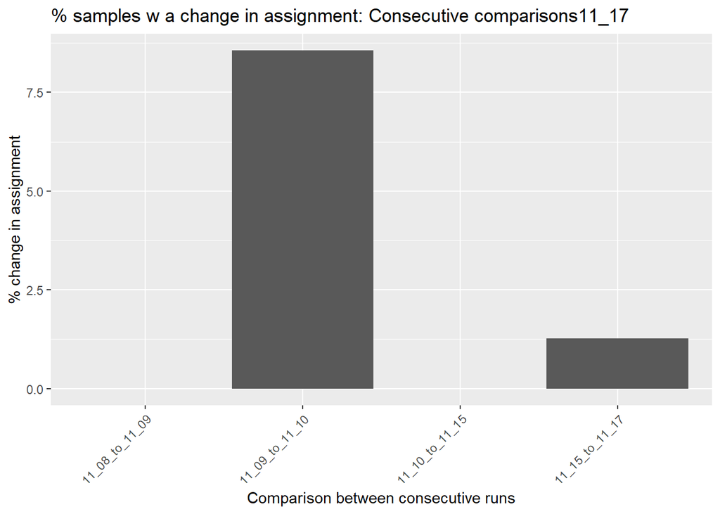

### Examining changes per lineage with counts versus percentage

One way to flag lineages with less steady assignment in question: - A bionimial test was conducted per lineage with the probability of change set to 10%, and subsequently the Bonferonni multiple hypothesis testing correction was followed. - The scatter plot highlights the percent and count changes per lineage, represented as points. These points are colored by its significance in changes. The color legend reflects the level of significance in change from binomial tests: -log10(Bonferroni-corrected p). Top 10 significant lineages or those with > 100 changes in counts were labeled in the figure.

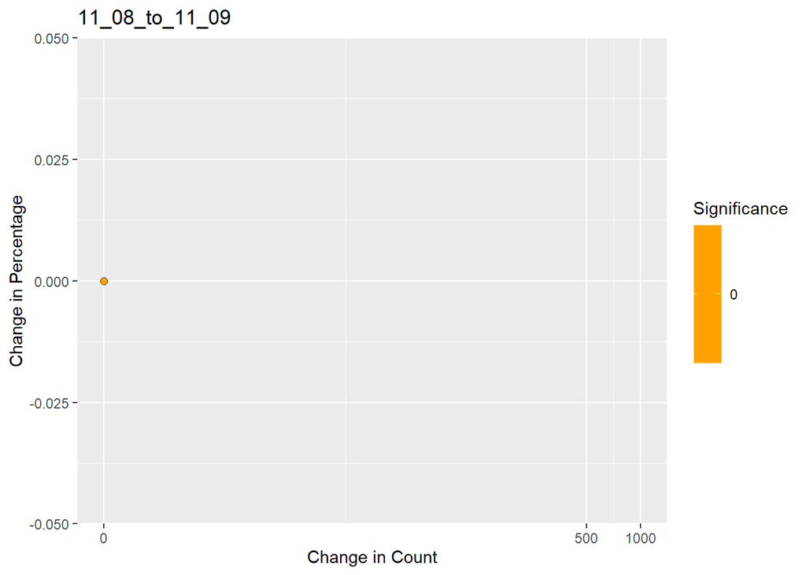

```
## [1] "Top 10 significant changes 11_08_to_11_09"
## [1] "None"
```

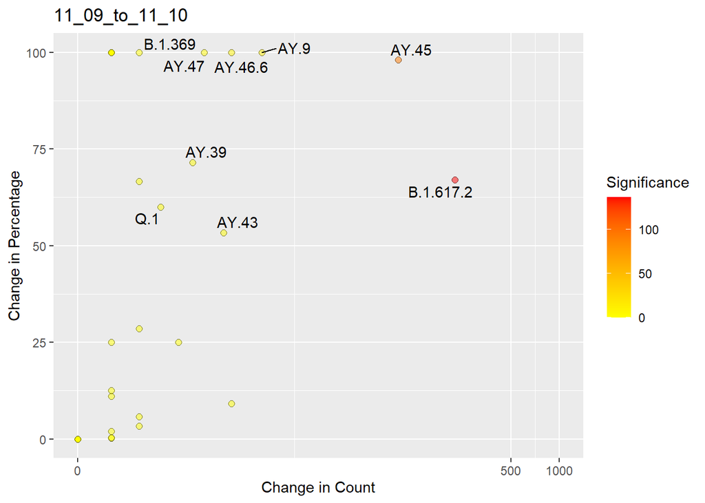

```
## [1] "Top 10 significant changes 11_09_to_11_10"
##           count   percent          adjp
## B.1.617.2   223  66.96697 1.020316e-137
## AY.45        99  98.01980  1.639840e-95
## AY.9         14 100.00000  2.000000e-14
## AY.46.6       9 100.00000  2.000000e-09
## AY.47         6 100.00000  4.000000e-06
## AY.43         8  53.33333  1.344996e-04
## AY.39         5  71.42857  7.060000e-04
## Q.1           3  60.00000  3.424000e-02
## B.1.369       2 100.00000  4.000000e-02
```

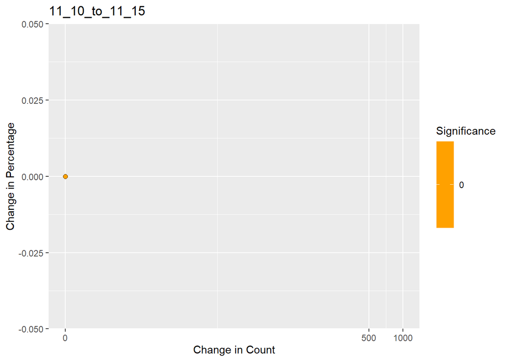

```
## [1] "Top 10 significant changes 11_10_to_11_15"
## [1] "None"
```

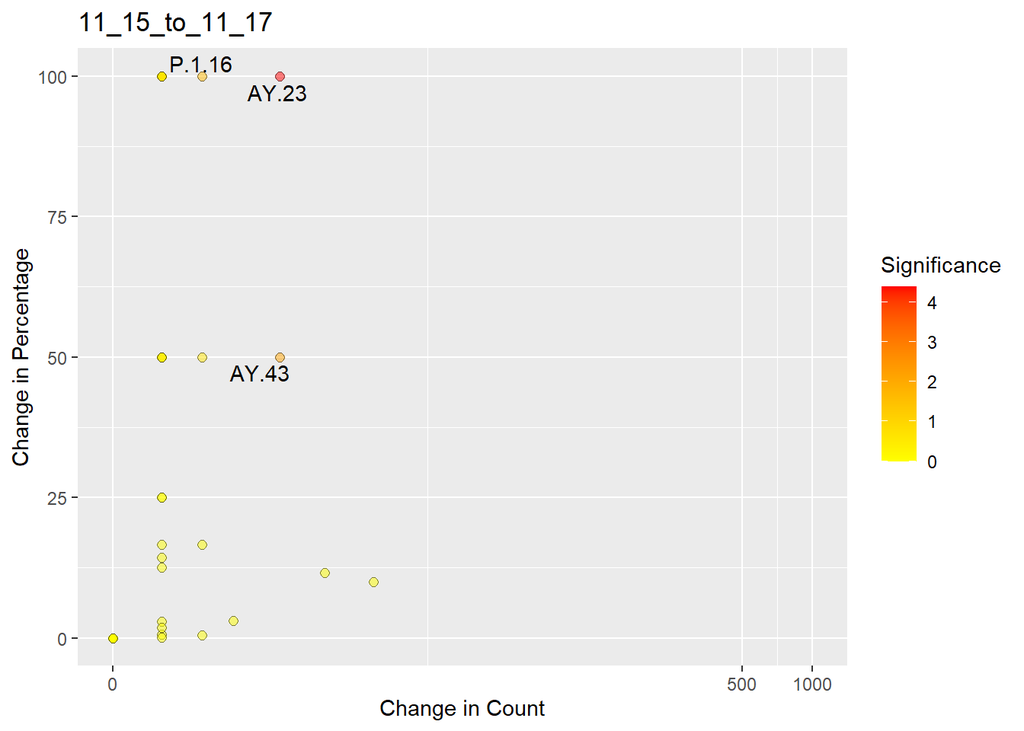

```
## [1] "Top 10 significant changes 11_15_to_11_17"
##        count percent       adjp
## AY.23      5     100 0.00004000
## AY.43      5      50 0.00653975
## P.1.16     2     100 0.02000000
```

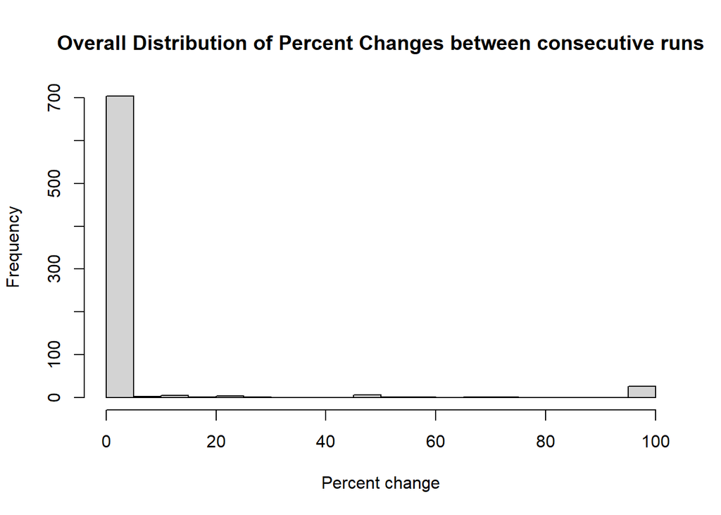

### Examining pairs of lineage changes between two timepoints

Top 5 pairs between two timepoints are visualized in a pie chart with counts of samples labeled, if there is any change between two timepoints.

```
## [1] "No changes in 11_08_to_11_09"
```

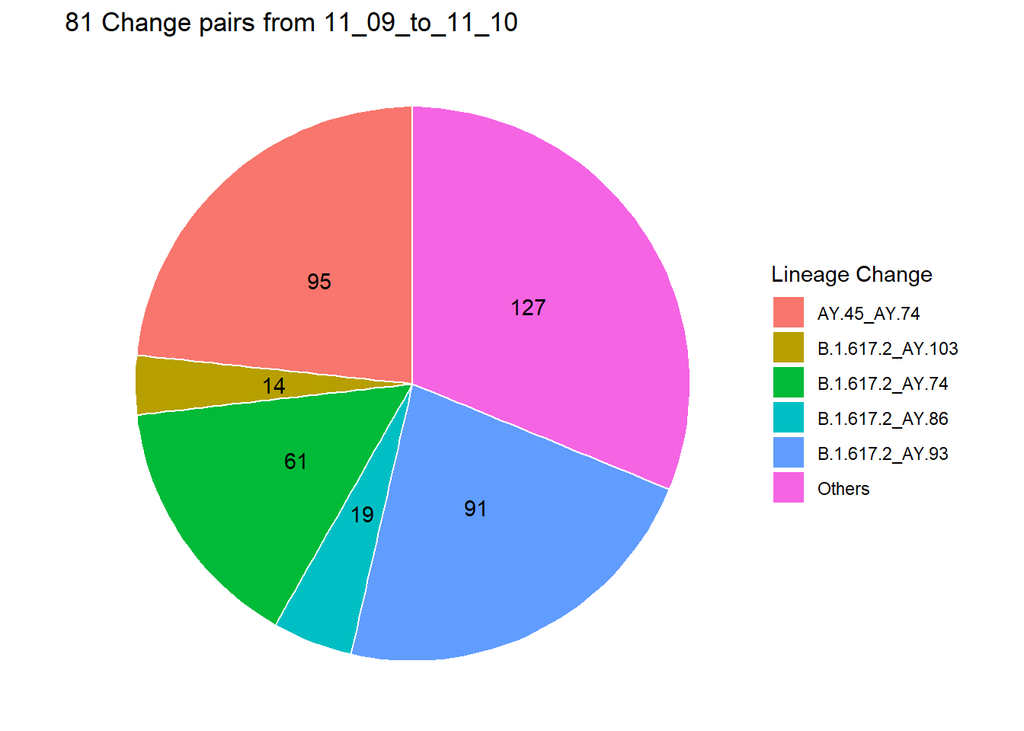

```
## [1] "No changes in 11_10_to_11_15"
```

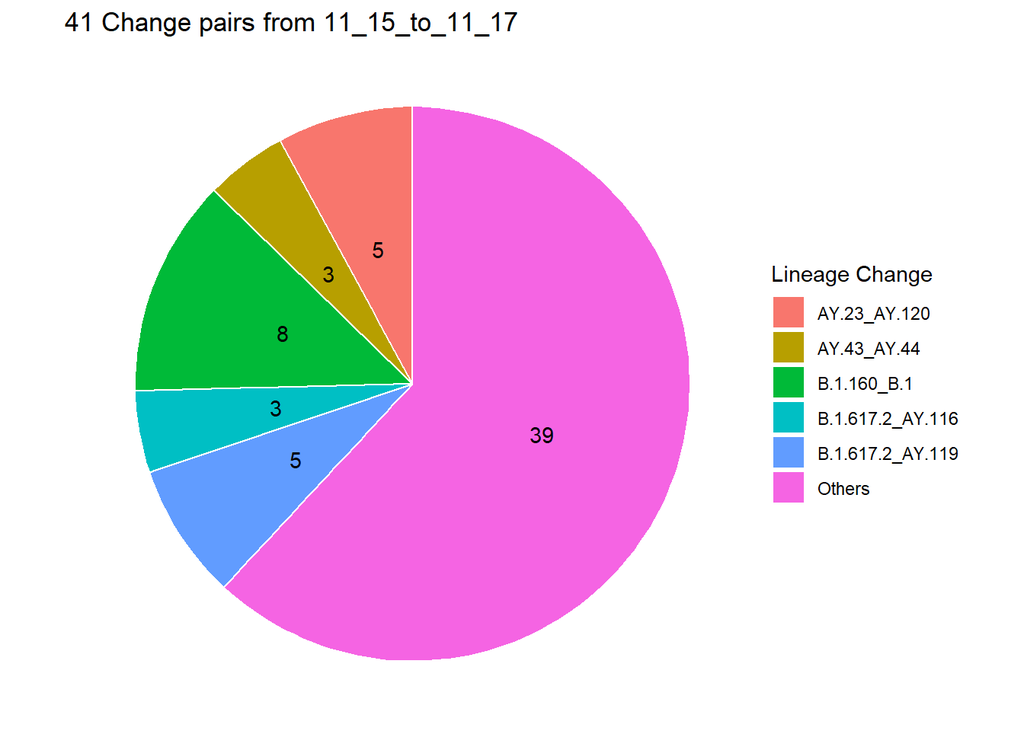

```
## [1] "Printing top 10 change pairs or those with changes of > 50 samples"
```

```
## $`11_08_to_11_09`
## integer(0)
##
## $`11_09_to_11_10`
##
##       AY.45_AY.74   B.1.617.2_AY.93   B.1.617.2_AY.74   B.1.617.2_AY.86
##                95                91                61                19
##  B.1.617.2_AY.103     AY.9_AY.9.2.1   B.1.617.2_AY.61 AY.46.6_B.1.617.2
##                14                13                10                 8
##       B.1_B.1.160       AY.15_AY.13
##                 7                 3
##
## $`11_10_to_11_15`
## integer(0)
##
## $`11_15_to_11_17`
##
##      B.1.160_B.1     AY.23_AY.120 B.1.617.2_AY.119      AY.43_AY.44 B.1.617.2_AY.116
##                8                5                5                3                3
##      AY.15_AY.38 B.1.617.2_AY.113       P.1.16_P.1      AY.27_AY.37      AY.27_AY.74
##                2                2                2                1                1
```